# Multinomial Logit and Truncation Model

Nhat My Thien Nguyen

4/28/2021

```r
knitr::opts_chunk$set(echo = TRUE)

library(PoEdata); library(xtable); library(knitr); library(lmtest); library(zoo);library(carData);library(sandwich);library(ggplot2);library(gridExtra);library(lmtest);library(readxl);library(car);library(stargazer);library(lattice);library(survival);library(Formula);library(nortest);library(foreign);library(nnet);library(reshape2);library(readxl); library(kableExtra); library(xtable); library(knitr); library("tidyr");library(tidyverse);library(broom);library(AER); library(systemfit); library(nnet); library(censReg); library(truncreg); library(dynlm);library(orcutt); library(nlWaldTest);library(pdfetch); library(forecast); library(TTR); library(tseries); library(censReg)
```

# Problem 1

```r
heating<-read_csv("Heating.csv")
```

1. Run a multinomial regression to explain how income, rooms and agehed explain the choice of the heating system chosen by a household.

```r
heat_multi<-multinom(depvar~income+rooms+agehed,data=heating)
summary(heat_multi)
```

```
## Call:
## multinom(formula = depvar ~ income + rooms + agehed, data = heating)
##
## Coefficients:
##    (Intercept)       income       rooms       agehed
## gc   2.7057020 -0.005651584 -0.06389405 -0.004562022
## hp   0.4227525  0.066388546 -0.04125778 -0.018892734
##
## Std. Errors:
##    (Intercept)     income    rooms      agehed
## gc   0.6520396 0.07848707 0.076803 0.009353178
## hp   0.9238766 0.11341634 0.109904 0.013442778
##
## Residual Deviance: 770.1182
## AIC: 786.1182
```

2. Are any of the explanatory variables significant at a 5 percent level of significance?

```r
z<-summary(heat_multi)$coefficients/summary(heat_multi)$standard.errors
p<-(1-pnorm(abs(z),0,1))*2
paste("The following are the p-values for the multinomial regression coefficients")
```

```
## [1] "The following are the p-values for the multinomial regression coefficients"
```

```r
p
```

```
##     (Intercept)    income     rooms    agehed
## gc 3.330599e-05 0.9425967 0.4054534 0.6257262
## hp 6.472503e-01 0.5583107 0.7073642 0.1598968
```

We can see that none of the explanatory variables are significant at a 5 percent level of significance.

3. Use the results of the multinomial regression and the predict() function, to predict the probabilities of a household’s choosing the 3 heating systems at the median values of all x variables.

```r
medincome<-quantile(heating$income,.5)
medroom<-quantile(heating$rooms,.5)
medagehed<-quantile(heating$agehed,.5)

newdat<-data.frame(income=c(medincome),rooms=c(medroom),agehed=c(medagehed))
pred<-predict(heat_multi,newdat,"probs")
pred
```

```
##         ec         gc         hp
## 0.09135318 0.83824465 0.07040217
```

At the median values of all x variables, the probabilities of a household’s choosing central electric heating system is 0.09, central gas is 0.84 and heat pump is 0.07.

# Problem 2

```r
htv<-read_excel("HTV.xlsx")
```

1. Using OLS on the full sample estimate a model for log(wage) using explanatory variables educ, abil, exper, nc, west, south and urban. Report the estimated effect of a year’s education and its standard error.

```r
htv.ols<-lm(lwage~educ+abil+exper+nc+west+south+urban,data = htv)
summary(htv.ols)
```

```
##
## Call:
## lm(formula = lwage ~ educ + abil + exper + nc + west + south +
##     urban, data = htv)
##
## Residuals:
##      Min       1Q   Median       3Q      Max
## -2.21523 -0.27733  0.03231  0.31225  1.77295
##
## Coefficients:
##              Estimate Std. Error t value Pr(>|t|)
## (Intercept)  0.398676   0.184763   2.158  0.03114 *
## educ         0.103718   0.009689  10.704  < 2e-16 ***
## abil         0.055781   0.008497   6.565 7.68e-11 ***
## exper        0.044822   0.006771   6.619 5.39e-11 ***
## nc          -0.139745   0.040619  -3.440  0.00060 ***
## west        -0.128237   0.048609  -2.638  0.00844 **
## south       -0.122691   0.044742  -2.742  0.00619 **
## urban        0.226785   0.040578   5.589 2.82e-08 ***
## ---
## Signif. codes:  0 '***' 0.001 '**' 0.01 '*' 0.05 '.' 0.1 ' ' 1
##
## Residual standard error: 0.5212 on 1222 degrees of freedom
## Multiple R-squared:  0.2337, Adjusted R-squared:  0.2293
## F-statistic: 53.23 on 7 and 1222 DF,  p-value: < 2.2e-16
```

The coefficient of year’s education is 0.1037 and its standard error is 0.0097

2. Now assume any observation with wage ≥ 20 to have wage = 20 so that everyone from part (a) still remains in the sample, but if they earn above $20 an hour, then it is assumed as equal to $20. Run the regression from part (a) and comment on the coefficient on educ.

```r
updatehtv<-mutate(htv, newwage=ifelse(wage>=20,20,wage))
updatehtv
```

```
## # A tibble: 1,230 x 24
##     wage   abil  educ    ne    nc  west south exper motheduc fatheduc brkhme14
##    <dbl>  <dbl> <dbl> <dbl> <dbl> <dbl> <dbl> <dbl>    <dbl>    <dbl>    <dbl>
##  1 12.0   5.03     15     0     0     1     0     9       12       12        0
##  2  8.91  2.04     13     1     0     0     0     8       12       10        1
##  3 15.5   2.48     15     1     0     0     0    11       12       16        0
##  4 13.3   3.61     15     1     0     0     0     6       12       12        0
##  5 11.1   2.64     13     1     0     0     0    15       12       15        1
##  6 17.5   3.47     18     1     0     0     0     8       12       12        0
##  7 21.1  -1.76     13     1     0     0     0    13       13       12        0
##  8 11.7  -0.134    12     0     0     0     1    14       12       12        1
##  9 17.0   2.07     13     1     0     0     0     9       10       12        1
## 10 11.5  -0.338    12     1     0     0     0     9       14       12        0
## # ... with 1,220 more rows, and 13 more variables: sibs <dbl>, urban <dbl>,
## #   ne18 <dbl>, nc18 <dbl>, south18 <dbl>, west18 <dbl>, urban18 <dbl>,
## #   tuit17 <dbl>, tuit18 <dbl>, lwage <dbl>, expersq <dbl>, ctuit <dbl>,
## #   newwage <dbl>
```

```r
htv.ols2<-lm(log(newwage)~educ+abil+exper+nc+west+south+urban,data = updatehtv)
summary(htv.ols2)
```

```
##
## Call:
## lm(formula = log(newwage) ~ educ + abil + exper + nc + west +
##     south + urban, data = updatehtv)
##
## Residuals:
##      Min       1Q   Median       3Q      Max
## -2.14936 -0.24922  0.07105  0.31554  1.05190
##
## Coefficients:
##              Estimate Std. Error t value Pr(>|t|)
## (Intercept)  0.837511   0.163424   5.125 3.46e-07 ***
## educ         0.078048   0.008570   9.107  < 2e-16 ***
## abil         0.056077   0.007516   7.461 1.62e-13 ***
## exper        0.033174   0.005989   5.539 3.73e-08 ***
## nc          -0.121668   0.035927  -3.386  0.00073 ***
## west        -0.121910   0.042995  -2.835  0.00465 **
## south       -0.110147   0.039574  -2.783  0.00546 **
## urban        0.186069   0.035892   5.184 2.54e-07 ***
## ---
## Signif. codes:  0 '***' 0.001 '**' 0.01 '*' 0.05 '.' 0.1 ' ' 1
##
## Residual standard error: 0.461 on 1222 degrees of freedom
## Multiple R-squared:  0.2206, Adjusted R-squared:  0.2161
## F-statistic: 49.41 on 7 and 1222 DF,  p-value: < 2.2e-16
```

The coefficient of year’s education is down to 0.078 and its standard error is also narrower 0.0086 comparing to first model.

3. Using the sample in part (b) apply a censoring regression. Does the censoring correction appear to recover the effect of educ in the full population?

```r
htv.censored<-censReg(log(wage)~educ+abil+exper+nc+west+south+urban,right=log(20),data=htv)
summary(htv.censored)
```

```
##
## Call:
## censReg(formula = log(wage) ~ educ + abil + exper + nc + west +
##     south + urban, right = log(20), data = htv)
##
## Observations:
##          Total  Left-censored     Uncensored Right-censored
##           1230              0           1066            164
##
## Coefficients:
##              Estimate Std. error t value  Pr(> t)
## (Intercept)  0.515481   0.186001   2.771  0.00558 **
## educ         0.097923   0.009812   9.980  < 2e-16 ***
## abil         0.058540   0.008444   6.933 4.12e-12 ***
## exper        0.041395   0.006779   6.107 1.02e-09 ***
## nc          -0.134978   0.040732  -3.314  0.00092 ***
## west        -0.134460   0.048789  -2.756  0.00585 **
## south       -0.119192   0.044869  -2.656  0.00790 **
## urban        0.211155   0.040276   5.243 1.58e-07 ***
## logSigma    -0.668121   0.022229 -30.056  < 2e-16 ***
## ---
## Signif. codes:  0 '***' 0.001 '**' 0.01 '*' 0.05 '.' 0.1 ' ' 1
##
## Newton-Raphson maximisation, 5 iterations
## Return code 8: successive function values within relative tolerance limit (reltol)
## Log-likelihood: -960.1693 on 9 Df
```

The coeffiction of edu is 0.098, higher than that in part b. And its standard errors is 0.0098, which is a little bit higher than that of part a, so the censoring correction appear to recover the effect of educ in the full population

4. Now drop all observations with wage ≥ 20, so that everyone remaining in the sample earns less than $20 an hour. Run the regression from part (a) and comment on the coefficient on educ.

```r
newhtv<-filter(htv,wage<20)
newhtv
```

```
## # A tibble: 1,066 x 23
##     wage   abil  educ    ne    nc  west south exper motheduc fatheduc brkhme14
##    <dbl>  <dbl> <dbl> <dbl> <dbl> <dbl> <dbl> <dbl>    <dbl>    <dbl>    <dbl>
##  1 12.0   5.03     15     0     0     1     0     9       12       12        0
##  2  8.91  2.04     13     1     0     0     0     8       12       10        1
##  3 15.5   2.48     15     1     0     0     0    11       12       16        0
##  4 13.3   3.61     15     1     0     0     0     6       12       12        0
##  5 11.1   2.64     13     1     0     0     0    15       12       15        1
##  6 17.5   3.47     18     1     0     0     0     8       12       12        0
##  7 11.7  -0.134    12     0     0     0     1    14       12       12        1
##  8 17.0   2.07     13     1     0     0     0     9       10       12        1
##  9 11.5  -0.338    12     1     0     0     0     9       14       12        0
## 10 14.8   1.38     12     1     0     0     0    13        9       10        1
## # ... with 1,056 more rows, and 12 more variables: sibs <dbl>, urban <dbl>,
## #   ne18 <dbl>, nc18 <dbl>, south18 <dbl>, west18 <dbl>, urban18 <dbl>,
## #   tuit17 <dbl>, tuit18 <dbl>, lwage <dbl>, expersq <dbl>, ctuit <dbl>
```

```r
htv.ols3<-lm(lwage~educ+abil+exper+nc+west+south+urban,data = newhtv)
summary(htv.ols3)
```

```
##
## Call:
## lm(formula = lwage ~ educ + abil + exper + nc + west + south +
##     urban, data = newhtv)
##
## Residuals:
##      Min       1Q   Median       3Q      Max
## -2.06781 -0.22584  0.07664  0.31729  0.99548
##
## Coefficients:
##              Estimate Std. Error t value Pr(>|t|)
## (Intercept)  1.179513   0.173593   6.795 1.81e-11 ***
## educ         0.057923   0.009256   6.258 5.65e-10 ***
## abil         0.054799   0.007645   7.168 1.42e-12 ***
## exper        0.021757   0.006275   3.467 0.000547 ***
## nc          -0.137305   0.037683  -3.644 0.000282 ***
## west        -0.141490   0.045350  -3.120 0.001858 **
## south       -0.117571   0.041502  -2.833 0.004700 **
## urban        0.165302   0.036529   4.525 6.72e-06 ***
## ---
## Signif. codes:  0 '***' 0.001 '**' 0.01 '*' 0.05 '.' 0.1 ' ' 1
##
## Residual standard error: 0.4476 on 1058 degrees of freedom
## Multiple R-squared:  0.183,  Adjusted R-squared:  0.1776
## F-statistic: 33.85 on 7 and 1058 DF,  p-value: < 2.2e-16
```

The coefficient of edu in this case is lower than above regression, it might be due to cut-off observations in sample.

5. Using the sample in part (d) apply a truncated regression [with the upper truncation point being log(20)]. Does the truncated regression appear to recover the effect of educ in the full population?

```r
htv.truncated<-truncreg(lwage~educ+abil+exper+nc+west+south+urban,data=newhtv,point=log(20),direction="right")
summary(htv.truncated)
```

```
##
## Call:
## truncreg(formula = lwage ~ educ + abil + exper + nc + west +
##     south + urban, data = newhtv, point = log(20), direction = "right")
##
## BFGS maximization method
## 74 iterations, 0h:0m:0s
## g'(-H)^-1g = 5.41E-08
##
##
##
## Coefficients :
##              Estimate Std. Error t-value  Pr(>|t|)
## (Intercept)  0.609417   0.302007  2.0179 0.0436023 *
## educ         0.106038   0.016800  6.3117 2.759e-10 ***
## abil         0.081836   0.012693  6.4475 1.137e-10 ***
## exper        0.035639   0.010771  3.3089 0.0009365 ***
## nc          -0.255196   0.068335 -3.7345 0.0001881 ***
## west        -0.265215   0.081156 -3.2679 0.0010833 **
## south       -0.207896   0.073759 -2.8186 0.0048234 **
## urban        0.265683   0.059323  4.4785 7.515e-06 ***
## sigma        0.580815   0.022455 25.8652 < 2.2e-16 ***
## ---
## Signif. codes:  0 '***' 0.001 '**' 0.01 '*' 0.05 '.' 0.1 ' ' 1
##
## Log-Likelihood: -513.75 on 9 Df
```

The coefficient of edu is 0.106, higher than that of OLS in part d. This seems more reasonable and appears to recover the returns to education to the number from full population.

# Problem 3

```r
metalprice<-read_excel("MetalPrice.xlsx")
```

1. Is any of the “smoothing” methods appropriate in forecasting the time series?
2. If your answer to part (a) is “yes”, what “smoothing” model do you think is best suited for this forecasting and why?

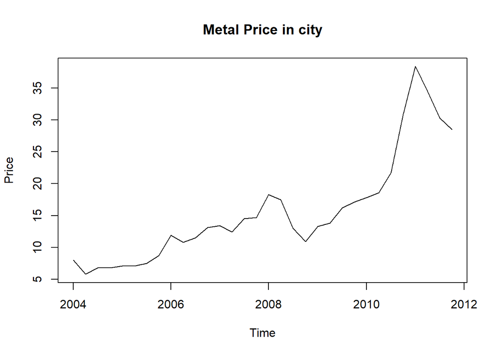

```r
price<-metalprice[,2]
price.ts<-ts(price,frequency=4, start=c(2004,1))
plot.ts(price.ts,main="Metal Price in city",xlab="Time",ylab="Price")
```

Let’s analyze the different components of price time series by decompose function

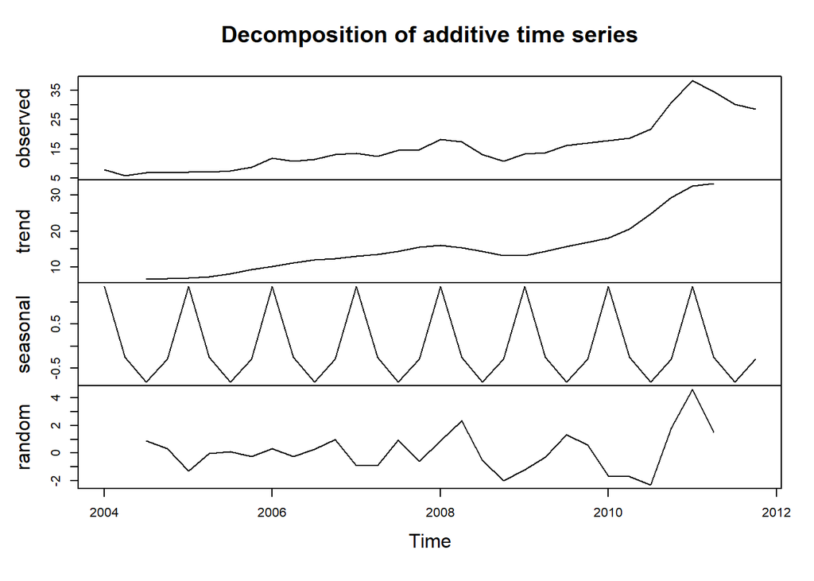

```r
pricecomponents<-decompose(price.ts)
plot(pricecomponents)
```

The decomposition shows the price time series has both trend and seasonality => So we can use Holt’s Exponential Smoothing method with both Trend and Seasonality in forecasting.

```r
priceforecasts_HW<-HoltWinters(price.ts)
priceforecasts_HW
```

```
## Holt-Winters exponential smoothing with trend and additive seasonal component.
##
## Call:
## HoltWinters(x = price.ts)
##
## Smoothing parameters:
##  alpha: 1
##  beta : 0.001200806
##  gamma: 0
##
## Coefficients:
##          [,1]
## a  28.4562500
## b   0.2315081
## s1  0.0937500
## s2 -0.2312500
## s3  0.0937500
## s4  0.0437500
```

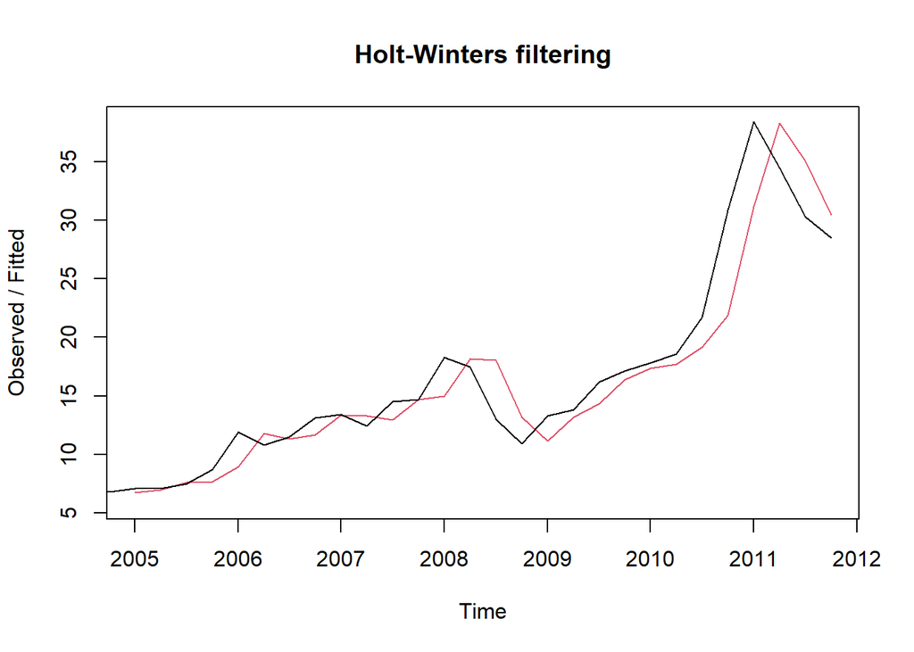

```r
plot(priceforecasts_HW)
```

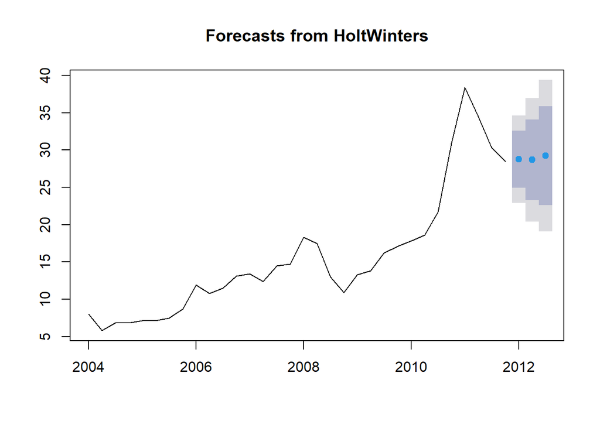

```r
priceforecasts_HW2<-forecast(priceforecasts_HW,3)
plot(priceforecasts_HW2)
```

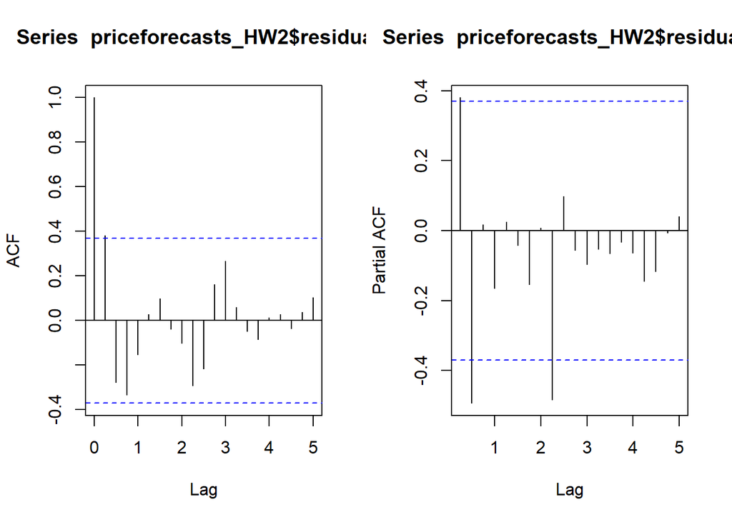

```r
par(mfrow=c(1,2))
acf(priceforecasts_HW2$residuals, lag.max=20, na.action = na.contiguous)
pacf(priceforecasts_HW2$residuals, lag.max=20, na.action = na.contiguous)
```

```r
Box.test(priceforecasts_HW2$residuals, lag=20, type="Ljung-Box")
```

```
##
##  Box-Ljung test
##
## data:  priceforecasts_HW2$residuals
## X-squared = 25.602, df = 20, p-value = 0.1794
```

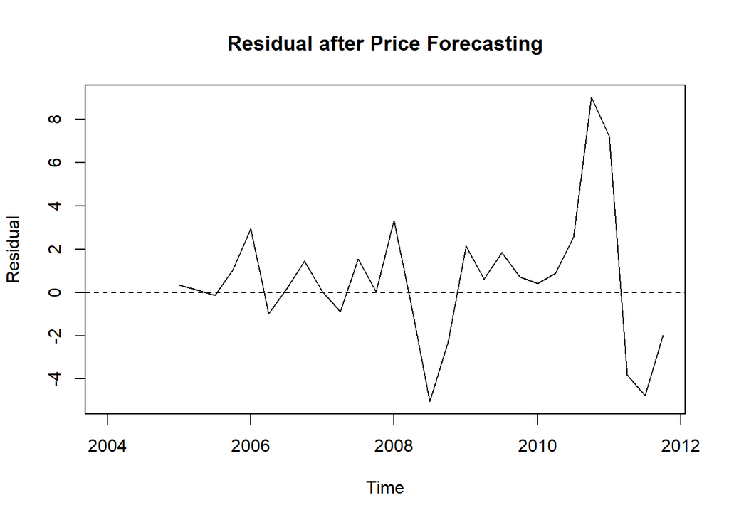

```r
plot.ts(priceforecasts_HW2$residuals, main="Residual after Price Forecasting",ylab="Residual")
abline(h=0,lty=2)
```

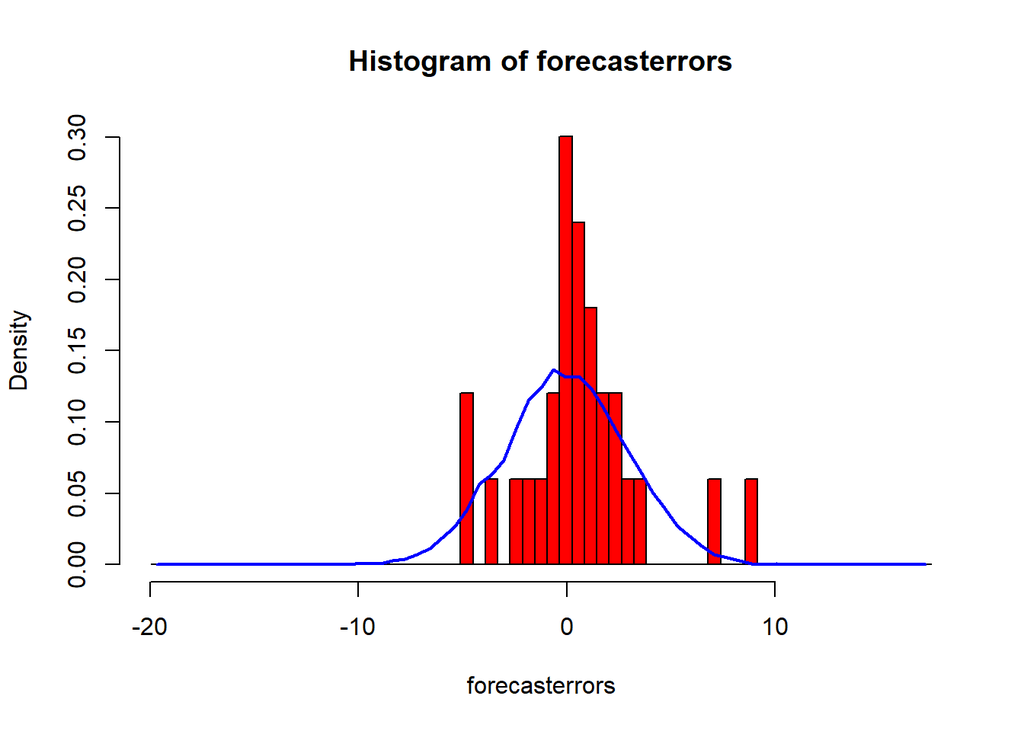

```r
plotForecastErrors <- function(forecasterrors)
{
# make a histogram of the forecast errors:
mybinsize <- IQR(forecasterrors)/4
mysd <- sd(forecasterrors)
mymin <- min(forecasterrors) - mysd*5
mymax <- max(forecasterrors) + mysd*3
# generate normally distributed data with mean 0 and standard deviation mysd
mynorm <- rnorm(10000, mean=0, sd=mysd)
mymin2 <- min(mynorm)
mymax2 <- max(mynorm)
if (mymin2 < mymin) { mymin <- mymin2 }
if (mymax2 > mymax) { mymax <- mymax2 }
# make a red histogram of the forecast errors, with the normally distributed data overlaid:
mybins <- seq(mymin, mymax, mybinsize)
hist(forecasterrors, col="red", freq=FALSE, breaks=mybins)
# freq=FALSE ensures the area under the histogram = 1
# generate normally distributed data with mean 0 and standard deviation mysd
myhist <- hist(mynorm, plot=FALSE, breaks=mybins)
# plot the normal curve as a blue line on top of the histogram of forecast errors:
points(myhist$mids, myhist$density, type="l", col="blue", lwd=2)
}

completerecords<-na.omit(priceforecasts_HW2$residuals)
plotForecastErrors(completerecords)
```

3. If not, determine, which order ARIMA model bests suits the data

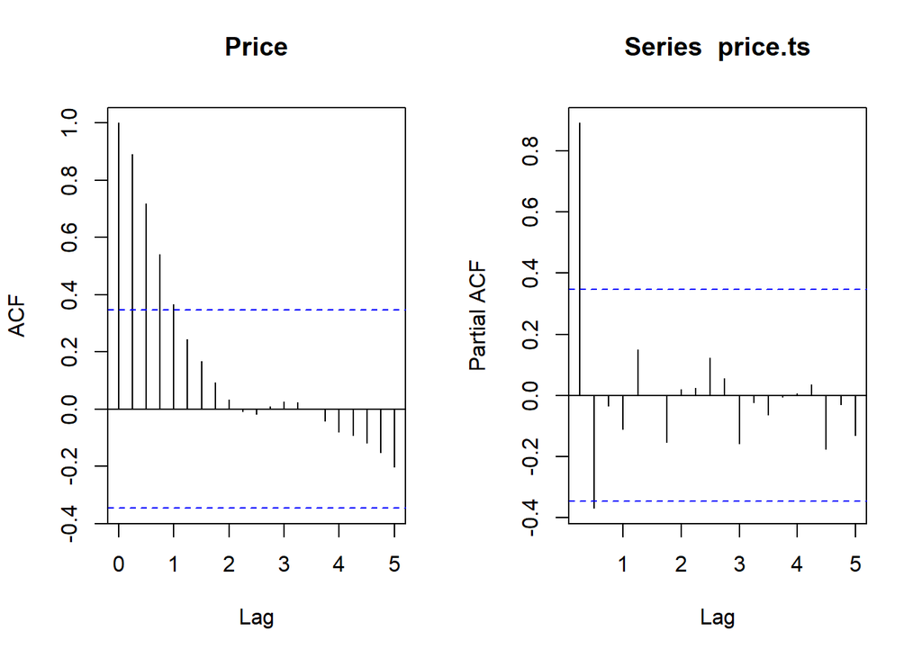

```r
par(mfrow=c(1,2))
acf(price.ts,lag.max=20)
pacf(price.ts,lag.max=20)
```

```r
auto.arima(price.ts)
```

```
## Series: price.ts
## ARIMA(0,1,1)
##
## Coefficients:
##          ma1
##       0.4982
## s.e.  0.1295
##
## sigma^2 estimated as 6.878:  log likelihood=-73.51
## AIC=151.02   AICc=151.45   BIC=153.89
```

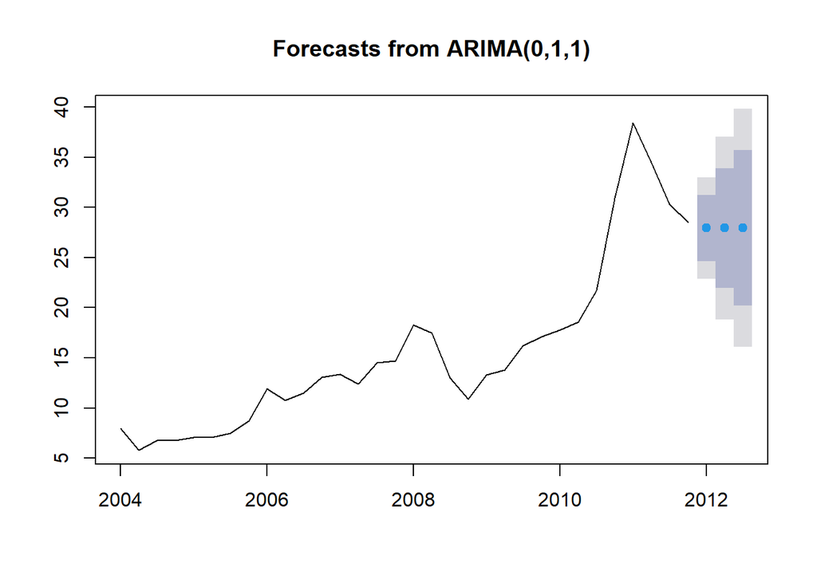

```r
price.arima<-arima(price.ts,order=c(0,1,1))
price.arimaforecast<-forecast(price.arima,3)
plot(price.arimaforecast)
```

Compare fits between ARIMA and the HoltWinter forecasting

```r
accuracy(priceforecasts_HW2)
```

```
##                     ME     RMSE      MAE      MPE     MAPE      MASE      ACF1
## Training set 0.5653369 2.985097 2.037037 2.584975 10.84219 0.4106339 0.3804249
```

```r
accuracy(price.arimaforecast)
```

```
##                     ME     RMSE      MAE      MPE     MAPE      MASE
## Training set 0.4183805 2.539299 1.907999 1.996673 12.60843 0.3846218
##                     ACF1
## Training set 0.007116823
```

4. Produce a 3-period forecast using the best model.

As we can see the ARIMA model is better than HoltWinter, so I will produce a 3-period forecast using the ARIMA model.

```r
price.arimaforecast
```

```
##         Point Forecast    Lo 80    Hi 80    Lo 95    Hi 95
## 2012 Q1       27.93889 24.63257 31.24520 22.88232 32.99546
## 2012 Q2       27.93889 21.98335 33.89443 18.83068 37.04710
## 2012 Q3       27.93889 20.19259 35.68519 16.09195 39.78583
```